# Agentic-Chunking

#### Agentic Chunking

**Task-Driven Approach:** Agentic chunking focuses on creating chunks that are directly relevant to the specific tasks an AI agent needs to perform, such as answering questions or summarizing text.

**Dynamic Segmentation:** Unlike fixed-size chunking, it uses AI to identify natural breakpoints in the text, like paragraph breaks or topic transitions, ensuring each chunk retains contextual meaning.

**LLM-Driven:** It leverages the power of Large Language Models (LLMs) to understand the text and make intelligent decisions about where to split it.

##### Example:

Imagine you have a long legal document, and you want to use it to answer questions about specific charges. Instead of splitting the document into fixed-size chunks, agentic chunking would:

- Identify Charges: Use an LLM to identify the different charges mentioned in the document.
- Create Chunks: Create a chunk for each charge, ensuring that all relevant information about that charge is included in one chunk.
- Enhance Retrieval: When a user asks a question about a specific charge, the AI can easily retrieve the relevant chunk, improving the accuracy and coherence of the answer.
- Identifying Charges:

The identify_charges function simulates charge detection in a legal document. In a real-world scenario, you would use Named Entity Recognition (NER) or an LLM model to extract charges from the document. For simplicity, we define three charges (Theft, Fraud, Assault).

- Creating Chunks:

The create_chunks_from_charges function creates text chunks based on the extracted charges. Each chunk corresponds to one charge, ensuring all relevant information about that charge is contained in a single chunk.

- Embedding and Storing in FAISS:

The SentenceTransformer is used to convert each chunk into a dense embedding vector.

These embeddings are added to a FAISS vector database (IndexFlatL2), which is optimized for fast similarity searches.

- Retrieving Relevant Chunks:

The retrieve_relevant_chunks function takes a user query, embeds it, and performs a nearest neighbor search in the FAISS index. It retrieves the top-k most similar chunks to the query.

- Unified Response (RAG):

The retrieved chunks are combined into a unified response using the generate_response_from_chunks function. This approach helps provide a coherent answer based on the relevant information retrieved from the chunks.

- Visualization:

```python
pip install transformers sentence-transformers faiss-cpu matplotlib
```

```python
pip install scikit-learn
```

```
Legal Document:
John Doe is accused of stealing electronics from a retail store. The items include laptops and smartphones.
John Doe allegedly submitted false tax returns, inflating his income to avoid paying taxes.
John Doe is accused of assaulting another person in a public space. The victim suffered minor injuries.


User Query:  Tell me about the theft charge.

Top-k Retrieved Chunks for the Query:
['John Doe is accused of stealing electronics from a retail store. The items include laptops and smartphones.']
```

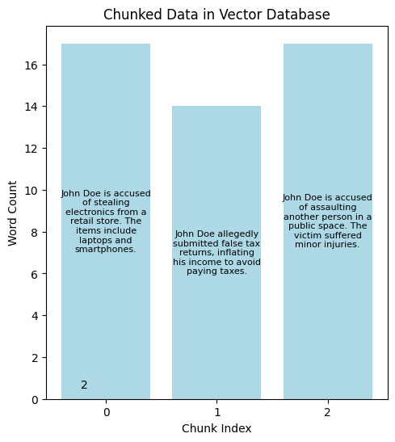

```python
import faiss
import numpy as np
from transformers import pipeline, GPT2Tokenizer, GPT2LMHeadModel
from sentence_transformers import SentenceTransformer
import matplotlib.pyplot as plt
from sklearn.decomposition import PCA
from sklearn.metrics.pairwise import cosine_similarity
import textwrap  # Importing textwrap to wrap long text

# Step 1: Define the function to identify charges in the legal document
# For simplicity, simulate the detection of charges. Note : This can be refined using NLP techniques.
def identify_charges(document):
    # In a real-world scenario, charges would typically be extracted using Named Entity Recognition (NER) or Large Language Models (LLMs).
    # For the purpose of illustration, simulate this process by manually defining a few sample charges.

    charges = [
        {"charge": "Theft", "text": "John Doe is accused of stealing electronics from a retail store. The items include laptops and smartphones."},
        {"charge": "Fraud", "text": "John Doe allegedly submitted false tax returns, inflating his income to avoid paying taxes."},
        {"charge": "Assault", "text": "John Doe is accused of assaulting another person in a public space. The victim suffered minor injuries."}
    ]
    return charges

# Step 1: Define the function to identify charges in the legal document
def identify_charges(document):
    charges = [
        {"charge": "Theft", "text": "John Doe is accused of stealing electronics from a retail store. The items include laptops and smartphones."},
        {"charge": "Fraud", "text": "John Doe allegedly submitted false tax returns, inflating his income to avoid paying taxes."},
        {"charge": "Assault", "text": "John Doe is accused of assaulting another person in a public space. The victim suffered minor injuries."}
    ]
    return charges

# Step 2: Chunking the document based on identified charges
def create_chunks_from_charges(charges):
    chunks = []
    for charge in charges:
        chunk = charge["text"]
        chunks.append(chunk)
    return chunks

# Example legal document (simulated as charges for simplicity)
document = """
John Doe is accused of stealing electronics from a retail store. The items include laptops and smartphones.
John Doe allegedly submitted false tax returns, inflating his income to avoid paying taxes.
John Doe is accused of assaulting another person in a public space. The victim suffered minor injuries.
"""

# Step 3: Embedding chunks using Sentence Transformers
embedding_model = SentenceTransformer('all-MiniLM-L6-v2')

# Identify charges in the document
charges = identify_charges(document)

# Create chunks based on the charges
chunks = create_chunks_from_charges(charges)

# Generate embeddings for the chunks
chunk_embeddings = embedding_model.encode(chunks)

# Step 4: Storing embeddings in FAISS (Vector Database)
index = faiss.IndexFlatL2(chunk_embeddings.shape[1])
index.add(np.array(chunk_embeddings))

# Step 5: Retrieval-Augmented Generation (RAG) - Retrieving relevant chunks based on query
def retrieve_relevant_chunks(query, k=3):
    query_embedding = embedding_model.encode([query])
    D, I = index.search(np.array(query_embedding), k)
    relevant_chunks = [chunks[i] for i in I[0]]
    return relevant_chunks

# Step 6: Query the system
user_query = "Tell me about the theft charge."
retrieved_chunks = retrieve_relevant_chunks(user_query, k=1)
print("\nLegal Document: ", document)
print("\nUser Query: ", user_query)
print("\nTop-k Retrieved Chunks for the Query:")
print(retrieved_chunks)
# Step 7: Recombine Chunks into a Unified Response
def generate_response_from_chunks(chunks):
    return " ".join(chunks)

unified_response = generate_response_from_chunks(retrieved_chunks)
#print("\nUnified Response:")
#print(unified_response)

# Step 8: Visualization of Embedding Data and Query Results

def plot_embeddings():
    pca = PCA(n_components=2)
    reduced_embeddings = pca.fit_transform(chunk_embeddings)

    query_embedding = embedding_model.encode([user_query])
    reduced_query_embedding = pca.transform(query_embedding)

    plt.figure(figsize=(12, 6))

    # Plot Chunk Bar Graph
    plt.subplot(1, 2, 1)
    word_counts = [len(chunk.split()) for chunk in chunks]
    plt.bar(range(len(chunks)), word_counts, color='lightblue')
    plt.title('Chunked Data in Vector Database')
    plt.xlabel('Chunk Index')
    plt.ylabel('Word Count')
    plt.xticks(range(len(chunks)), range(len(chunks)))

    # Add wrapped chunk data inside the bars
    for i, chunk in enumerate(chunks):
        # Wrap the chunk text using textwrap to fit it neatly inside the bar
        wrapped_text = textwrap.fill(chunk, width=20)  # Adjust width as needed
        plt.text(i, word_counts[i] / 2, wrapped_text, ha='center', va='center', fontsize=8, color='black')

    for i, txt in enumerate(chunks):
        plt.annotate(f"{i}", (reduced_embeddings[i, 0], reduced_embeddings[i, 1]))

# Plot the embeddings and the query results
plot_embeddings()
```

Linkedin: [Kumar N.P](https://www.linkedin.com/in/kumar-np)